# Census_income

### **70/30 %**

```r
classifier_2 = CBA(income ~ ., census_fact_2_tr, supp = 0.01, conf=0.68)
rules(classifier_2)
```

```
## set of 379 rules
```

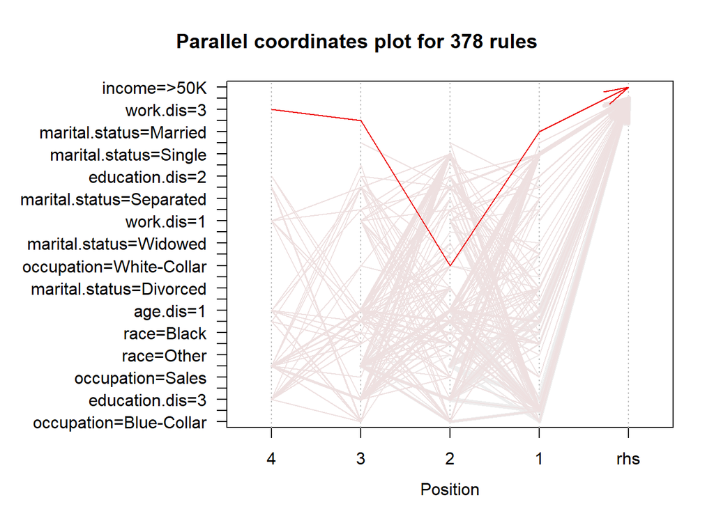

```r
rules_2.sorted = sort(rules(classifier_2), by = "lift")
rules_2.pruned = rules_2.sorted[!is.redundant(rules_2.sorted)]
predd_2 = predict(classifier_2, census_fact_2_ts)
plot(rules_2.pruned,method = "paracoord",measure = "support", shading = "lift", jitter = 0)
```

```r
table(predd_2,census_fact_2_ts$income)
```

```
##
## predd_2 <=50K >50K
##    <     7187 1701
##    >50K   177  703
```

The second model appears to be more complex with few extra rules generated. This has affected the accuracy as well. A slight increase - 80.80%. Missclassification rate - 19.20%.

### **60/40 %**

```r
classifier_3 = CBA(income ~ ., census_fact_3_tr, supp = 0.01, conf=0.68)
rules(classifier_3)
```

```
## set of 378 rules
```

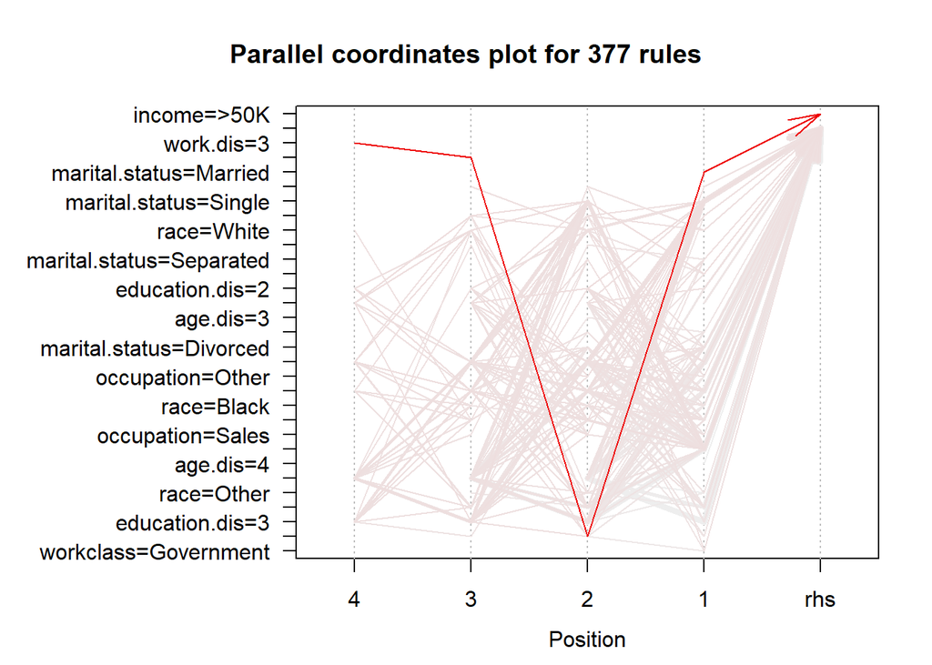

```r
rules_3.sorted = sort(rules(classifier_3), by = "lift")
rules_3.pruned = rules_3.sorted[!is.redundant(rules_3.sorted)]
predd_3 = predict(classifier_3, census_fact_3_ts)
plot(rules_3.pruned,method = "paracoord",measure = "support", shading = "lift", jitter = 0)
```

```r
table(predd_3,census_fact_3_ts$income)
```

```
##
## predd_3 <=50K >50K
##    <     9628 2302
##    >50K   218  876
```

## **Association Rules(Descriptive Analysis)**

This part shows the descriptive analysis of the dataset, based on association rules. This method only works on factor class data. All continuous attributes have already been discretized above. But for better understanding I will give each interval a specific.

```r
census_dis_rul = census[,]
census_dis_rul$age.dis  = findInterval(census_dis_rul$age, c(17,35,50,70,90))
census_dis_rul$education.dis  = findInterval(census_dis_rul$education.num, c(1,4,8,12))
census_dis_rul$work.dis  = findInterval(census_dis_rul$hours.per.week, c(1,25,50,75,99))
census_dis_rul$age.dis = as.factor(census_dis_rul$age.dis)
census_dis_rul$age.dis = revalue(census_dis_rul$age.dis, c("1"="young", "2"="adult", "3" = "mid.age", "4" = "old", "5" = "very.old"))
census_dis_rul$education.dis = as.factor(census_dis_rul$education.dis)
census_dis_rul$education.dis = revalue(census_dis_rul$education.dis, c("1" = "primitive", "2" = "educated", "3" = "intelligent", "4" = "genious"))
census_dis_rul$work.dis = as.factor(census_dis_rul$work.dis)
census_dis_rul$work.dis = revalue(census_dis_rul$work.dis, c("1"="free", "2"="hobby", "3" = "part.time", "4" = "full.time", "5" = "insane"))
fact_rul = sapply(census_dis_rul, is.factor)
census_fact_rul = census_dis_rul[, fact_rul]
census_fact_rul = census_fact_rul[c(1,2,3,4,5,7,8,9,6)]
```

Before creating associations the prepared data has to be reshaped as a transactions variable. This step must be done, because values in the factor levels aren’t represented as 0 or 1 in traditional market transactions. All of them have more than 2 categories. To view the frequency of values in the data set a special plot will be used with support greater than 10%.

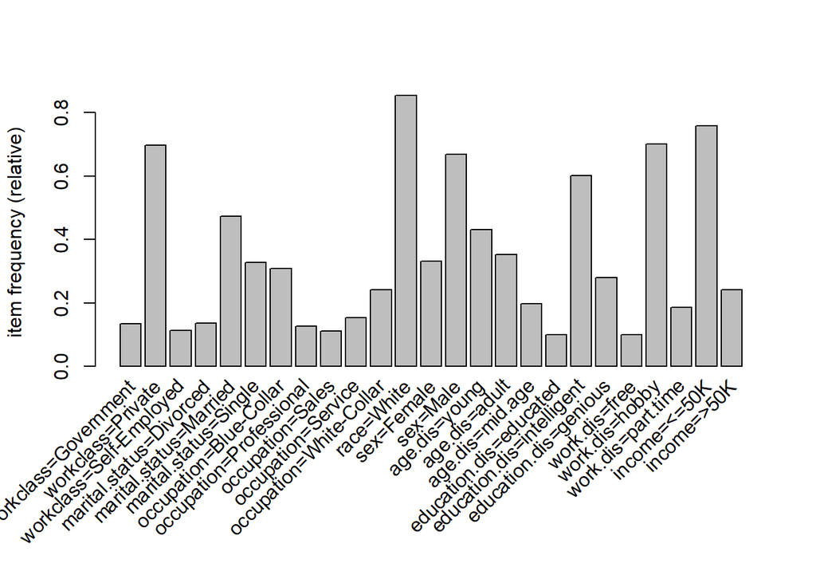

```r
census_tran_rul = as(census_fact_rul, "transactions")
itemFrequencyPlot(census_tran_rul,support=.10)
```

Firstly, i will display the summary of all rules generated with a minimum support of 1% and confidence of 69%.

```r
all_rules  = apriori(census_tran_rul,parameter=list(support=.01,confidence=.69,
minlen=2))
```

```
## Apriori
##
## Parameter specification:
##  confidence minval smax arem  aval originalSupport maxtime support minlen
##        0.69    0.1    1 none FALSE            TRUE       5    0.01      2
##  maxlen target  ext
##      10  rules TRUE
##
## Algorithmic control:
##  filter tree heap memopt load sort verbose
##     0.1 TRUE TRUE  FALSE TRUE    2    TRUE
##
## Absolute minimum support count: 325
##
## set item appearances ...[0 item(s)] done [0.00s].
## set transactions ...[36 item(s), 32561 transaction(s)] done [0.01s].
## sorting and recoding items ... [34 item(s)] done [0.00s].
## creating transaction tree ... done [0.01s].
## checking subsets of size 1 2 3 4 5 6 7 8 9 done [0.02s].
## writing ... [17901 rule(s)] done [0.00s].
## creating S4 object  ... done [0.01s].
```

```r
summary(all_rules)
```

```
## set of 17901 rules
##
## rule length distribution (lhs + rhs):sizes
##    2    3    4    5    6    7    8    9
##  104 1023 3756 6043 4671 1886  388   30
##
##    Min. 1st Qu.  Median    Mean 3rd Qu.    Max.
##   2.000   4.000   5.000   5.202   6.000   9.000
##
## summary of quality measures:
##     support          confidence        coverage            lift
##  Min.   :0.01001   Min.   :0.6900   Min.   :0.01004   Min.   : 0.8077
##  1st Qu.:0.01351   1st Qu.:0.7599   1st Qu.:0.01640   1st Qu.: 1.0464
##  Median :0.02024   Median :0.8325   Median :0.02445   Median : 1.1582
##  Mean   :0.03467   Mean   :0.8332   Mean   :0.04241   Mean   : 1.5265
##  3rd Qu.:0.03676   3rd Qu.:0.8989   3rd Qu.:0.04453   3rd Qu.: 1.3104
##  Max.   :0.63570   Max.   :1.0000   Max.   :0.85427   Max.   :17.5815
##      count
##  Min.   :  326
##  1st Qu.:  440
##  Median :  659
##  Mean   : 1129
##  3rd Qu.: 1197
##  Max.   :20699
##
## mining info:
##             data ntransactions support confidence
##  census_tran_rul         32561    0.01       0.69
```

17901 rules were generated in total using the provided support and confidence. Given that information, I will find all the rules, which are associated to *income*. Or in other words, I will find all the factors, which are associated to this attribute.

### **Income = >50K**

```r
income_above = apriori(census_tran_rul,parameter=list(supp=.01,conf=.6,minlen=2),appearance = list(default="rhs",lhs="income=>50K"))
```

```
## Apriori
##
## Parameter specification:
##  confidence minval smax arem  aval originalSupport maxtime support minlen
##         0.6    0.1    1 none FALSE            TRUE       5    0.01      2
##  maxlen target  ext
##      10  rules TRUE
##
## Algorithmic control:
##  filter tree heap memopt load sort verbose
##     0.1 TRUE TRUE  FALSE TRUE    2    TRUE
##
## Absolute minimum support count: 325
##
## set item appearances ...[1 item(s)] done [0.00s].
## set transactions ...[36 item(s), 32561 transaction(s)] done [0.01s].
## sorting and recoding items ... [34 item(s)] done [0.00s].
## creating transaction tree ... done [0.01s].
## checking subsets of size 1 2 done [0.00s].
## writing ... [5 rule(s)] done [0.00s].
## creating S4 object  ... done [0.00s].
```

```r
summary(income_above)
```

```
## set of 5 rules
##
## rule length distribution (lhs + rhs):sizes
## 2
## 5
##
##    Min. 1st Qu.  Median    Mean 3rd Qu.    Max.
##       2       2       2       2       2       2
##
## summary of quality measures:
##     support         confidence        coverage           lift
##  Min.   :0.1486   Min.   :0.6169   Min.   :0.2408   Min.   :0.8798
##  1st Qu.:0.1524   1st Qu.:0.6330   1st Qu.:0.2408   1st Qu.:0.9081
##  Median :0.2046   Median :0.8496   Median :0.2408   Median :1.0625
##  Mean   :0.1862   Mean   :0.7732   Mean   :0.2408   Mean   :1.1869
##  3rd Qu.:0.2069   3rd Qu.:0.8591   3rd Qu.:0.2408   3rd Qu.:1.2696
##  Max.   :0.2186   Max.   :0.9077   Max.   :0.2408   Max.   :1.8144
##      count
##  Min.   :4837
##  1st Qu.:4963
##  Median :6662
##  Mean   :6063
##  3rd Qu.:6736
##  Max.   :7117
##
## mining info:
##             data ntransactions support confidence
##  census_tran_rul         32561    0.01        0.6
```

It appears, that only a set of 5 rules was generated. However, there’s a possibility, that these rules can be redundant. To avoid redundancy, I will remove them.

```r
income_above[!is.redundant(income_above)]
```

```
## set of 5 rules
```

Looks like no redundant rules were generated. The list of all rules looks like this.

```r
inspect(sort(income_above, by ="lift"))
```

```
##     lhs              rhs                      support   confidence coverage
## [1] {income=>50K} => {marital.status=Married} 0.2068733 0.8590741  0.2408096
## [2] {income=>50K} => {sex=Male}               0.2046006 0.8496365  0.2408096
## [3] {income=>50K} => {race=White}             0.2185744 0.9076648  0.2408096
## [4] {income=>50K} => {workclass=Private}      0.1524216 0.6329550  0.2408096
## [5] {income=>50K} => {work.dis=hobby}         0.1485519 0.6168856  0.2408096
##     lift      count
## [1] 1.8143810 6736
## [2] 1.2696198 6662
## [3] 1.0624991 7117
## [4] 0.9080740 4963
## [5] 0.8798253 4837
```

It was already visible in the data preparation phase, which attribute factors are more likely to have *income* greater, than 50K. To understand this relation better a plot will be shown.

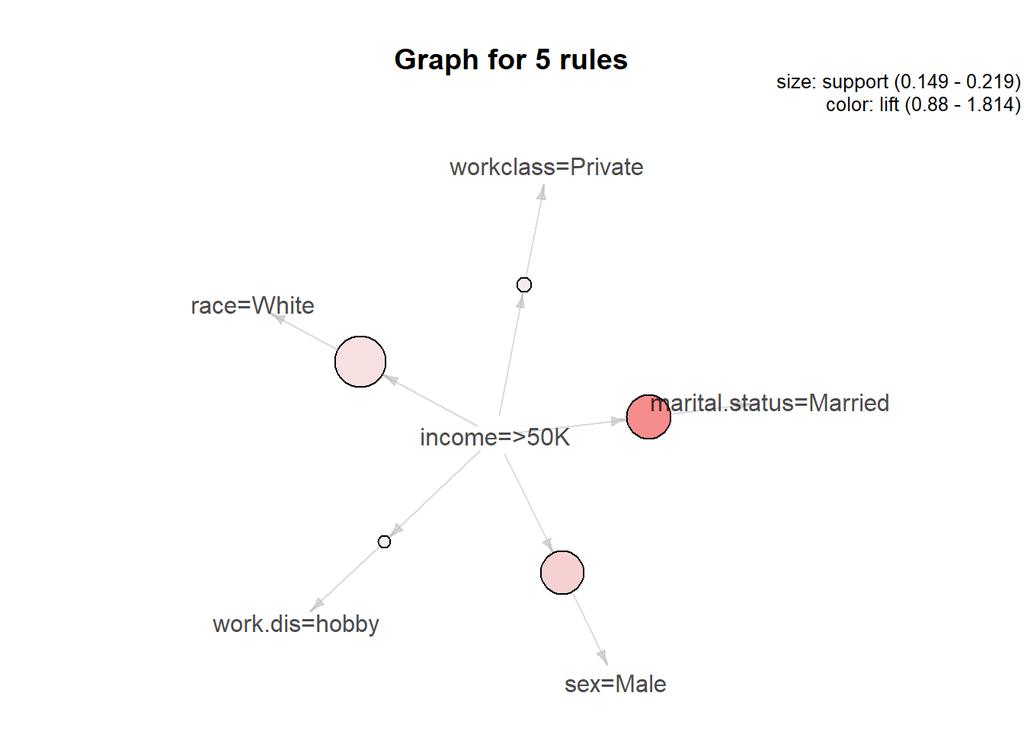

```r
plot(income_above,method="graph")
```

To view the rules from the other perspective, *income* will be placed on the right side this time.

```r
income_above_r = apriori(census_tran_rul,parameter=list(supp=.01,conf=.6,minlen=2),appearance = list(default="lhs",rhs="income=>50K"))
```

```
## Apriori
##
## Parameter specification:
##  confidence minval smax arem  aval originalSupport maxtime support minlen
##         0.6    0.1    1 none FALSE            TRUE       5    0.01      2
##  maxlen target  ext
##      10  rules TRUE
##
## Algorithmic control:
##  filter tree heap memopt load sort verbose
##     0.1 TRUE TRUE  FALSE TRUE    2    TRUE
##
## Absolute minimum support count: 325
##
## set item appearances ...[1 item(s)] done [0.00s].
## set transactions ...[36 item(s), 32561 transaction(s)] done [0.01s].
## sorting and recoding items ... [34 item(s)] done [0.00s].
## creating transaction tree ... done [0.01s].
## checking subsets of size 1 2 3 4 5 6 7 8 9 done [0.02s].
## writing ... [364 rule(s)] done [0.00s].
## creating S4 object  ... done [0.00s].
```

```r
summary(income_above_r)
```

```
## set of 364 rules
##
## rule length distribution (lhs + rhs):sizes
##   3   4   5   6   7   8
##   4  55 134 116  50   5
##
##    Min. 1st Qu.  Median    Mean 3rd Qu.    Max.
##   3.000   5.000   5.000   5.462   6.000   8.000
##
## summary of quality measures:
##     support          confidence        coverage            lift
##  Min.   :0.01001   Min.   :0.6003   Min.   :0.01142   Min.   :2.493
##  1st Qu.:0.01286   1st Qu.:0.6591   1st Qu.:0.01789   1st Qu.:2.737
##  Median :0.01741   Median :0.7086   Median :0.02491   Median :2.942
##  Mean   :0.02177   Mean   :0.7108   Mean   :0.03113   Mean   :2.952
##  3rd Qu.:0.02502   3rd Qu.:0.7550   3rd Qu.:0.03613   3rd Qu.:3.135
##  Max.   :0.10645   Max.   :0.8925   Max.   :0.15485   Max.   :3.706
##      count
##  Min.   : 326.0
##  1st Qu.: 418.8
##  Median : 567.0
##  Mean   : 708.8
##  3rd Qu.: 814.8
##  Max.   :3466.0
##
## mining info:
##             data ntransactions support confidence
##  census_tran_rul         32561    0.01        0.6
```

This time the generated number is much bigger than the previous one. 364 rules were created. This time there’s a higher possibility that at least some of them are redundant.

```r
income_above_sorted = income_above_r[!is.redundant(income_above_r)]
summary(income_above_sorted)
```

```
## set of 243 rules
##
## rule length distribution (lhs + rhs):sizes
##  3  4  5  6  7  8
##  4 47 99 67 24  2
##
##    Min. 1st Qu.  Median    Mean 3rd Qu.    Max.
##   3.000   5.000   5.000   5.272   6.000   8.000
##
## summary of quality measures:
##     support          confidence        coverage            lift
##  Min.   :0.01001   Min.   :0.6030   Min.   :0.01142   Min.   :2.504
##  1st Qu.:0.01331   1st Qu.:0.6575   1st Qu.:0.01798   1st Qu.:2.731
##  Median :0.01907   Median :0.7165   Median :0.02709   Median :2.975
##  Mean   :0.02335   Mean   :0.7167   Mean   :0.03327   Mean   :2.976
##  3rd Qu.:0.02647   3rd Qu.:0.7629   3rd Qu.:0.03923   3rd Qu.:3.168
##  Max.   :0.10645   Max.   :0.8925   Max.   :0.15485   Max.   :3.706
##      count
##  Min.   : 326.0
##  1st Qu.: 433.5
##  Median : 621.0
##  Mean   : 760.2
##  3rd Qu.: 862.0
##  Max.   :3466.0
##
## mining info:
##             data ntransactions support confidence
##  census_tran_rul         32561    0.01        0.6
```

```r
inspect(head(sort(income_above_sorted, by ="lift"),5))
```

```
##     lhs                          rhs              support confidence   coverage     lift count
## [1] {workclass=Private,
##      marital.status=Married,
##      occupation=White-Collar,
##      race=White,
##      sex=Male,
##      education.dis=genious,
##      work.dis=part.time}      => {income=>50K} 0.01019625  0.8924731 0.01142471 3.706137   332
## [2] {workclass=Private,
##      marital.status=Married,
##      occupation=White-Collar,
##      sex=Male,
##      education.dis=genious,
##      work.dis=part.time}      => {income=>50K} 0.01077977  0.8908629 0.01210037 3.699450   351
## [3] {workclass=Private,
##      marital.status=Married,
##      occupation=White-Collar,
##      race=White,
##      education.dis=genious,
##      work.dis=part.time}      => {income=>50K} 0.01074906  0.8883249 0.01210037 3.688910   350
## [4] {workclass=Private,
##      marital.status=Married,
##      occupation=White-Collar,
##      education.dis=genious,
##      work.dis=part.time}      => {income=>50K} 0.01136329  0.8872902 0.01280673 3.684614   370
## [5] {marital.status=Married,
##      occupation=White-Collar,
##      race=White,
##      sex=Male,
##      education.dis=genious,
##      work.dis=part.time}      => {income=>50K} 0.01464943  0.8656987 0.01692208 3.594952   477
```

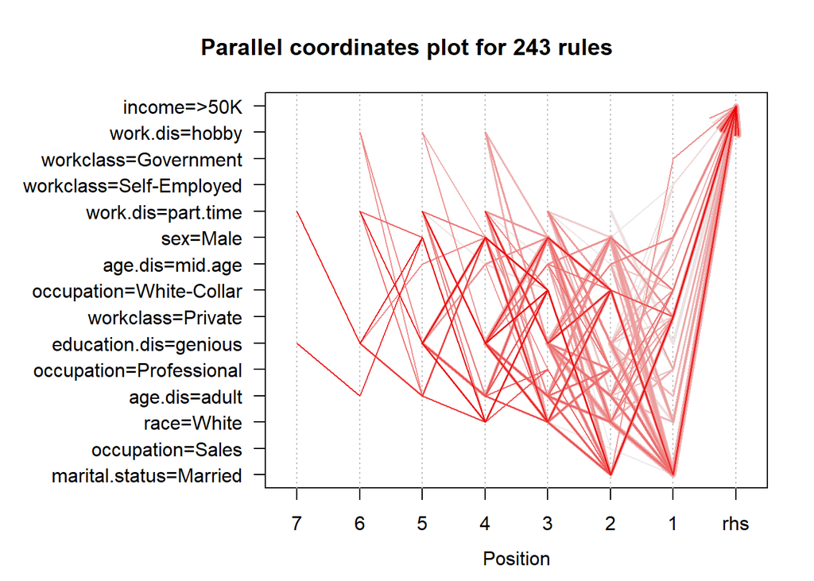

```r
plot(income_above_sorted,method="paracoord")
```

### **Income <= 50K**

The below 50K income side is needed for analysis as well. This will show the difference in their classification.

```r
income_below = apriori(census_tran_rul,parameter=list(supp=.01,conf=.6,minlen=2),appearance = list(default="rhs",lhs="income=<=50K"))
```

```
## Apriori
##
## Parameter specification:
##  confidence minval smax arem  aval originalSupport maxtime support minlen
##         0.6    0.1    1 none FALSE            TRUE       5    0.01      2
##  maxlen target  ext
##      10  rules TRUE
##
## Algorithmic control:
##  filter tree heap memopt load sort verbose
##     0.1 TRUE TRUE  FALSE TRUE    2    TRUE
##
## Absolute minimum support count: 325
##
## set item appearances ...[1 item(s)] done [0.00s].
## set transactions ...[36 item(s), 32561 transaction(s)] done [0.01s].
## sorting and recoding items ... [34 item(s)] done [0.00s].
## creating transaction tree ... done [0.01s].
## checking subsets of size 1 2 done [0.00s].
## writing ... [5 rule(s)] done [0.00s].
## creating S4 object  ... done [0.00s].
```

```r
summary(income_above)
```

```
## set of 5 rules
##
## rule length distribution (lhs + rhs):sizes
## 2
## 5
##
##    Min. 1st Qu.  Median    Mean 3rd Qu.    Max.
##       2       2       2       2       2       2
##
## summary of quality measures:
##     support         confidence        coverage           lift
##  Min.   :0.1486   Min.   :0.6169   Min.   :0.2408   Min.   :0.8798
##  1st Qu.:0.1524   1st Qu.:0.6330   1st Qu.:0.2408   1st Qu.:0.9081
##  Median :0.2046   Median :0.8496   Median :0.2408   Median :1.0625
##  Mean   :0.1862   Mean   :0.7732   Mean   :0.2408   Mean   :1.1869
##  3rd Qu.:0.2069   3rd Qu.:0.8591   3rd Qu.:0.2408   3rd Qu.:1.2696
##  Max.   :0.2186   Max.   :0.9077   Max.   :0.2408   Max.   :1.8144
##      count
##  Min.   :4837
##  1st Qu.:4963
##  Median :6662
##  Mean   :6063
##  3rd Qu.:6736
##  Max.   :7117
##
## mining info:
##             data ntransactions support confidence
##  census_tran_rul         32561    0.01        0.6
```

5 rules were generated. Despite this, redundancy check is still needed.

```r
income_below[!is.redundant(income_below)]
```

```
## set of 5 rules
```

No redundancy detected. Now the rules will be shown, being sorted by the lift metric.

```r
inspect(sort(income_below, by ="lift"))
```

```
##     lhs               rhs                         support   confidence
## [1] {income=<=50K} => {education.dis=intelligent} 0.4960228 0.6533576
## [2] {income=<=50K} => {work.dis=hobby}            0.5525936 0.7278722
## [3] {income=<=50K} => {workclass=Private}         0.5446086 0.7173544
## [4] {income=<=50K} => {race=White}                0.6356991 0.8373382
## [5] {income=<=50K} => {sex=Male}                  0.4646049 0.6119741
##     coverage  lift      count
## [1] 0.7591904 1.0850195 16151
## [2] 0.7591904 1.0381185 17993
## [3] 0.7591904 1.0291582 17733
## [4] 0.7591904 0.9801758 20699
## [5] 0.7591904 0.9144786 15128
```

Some rules on the right side have a bit similar to those created for >50K income. This is explained by class imbalance, where <=50K is leading.

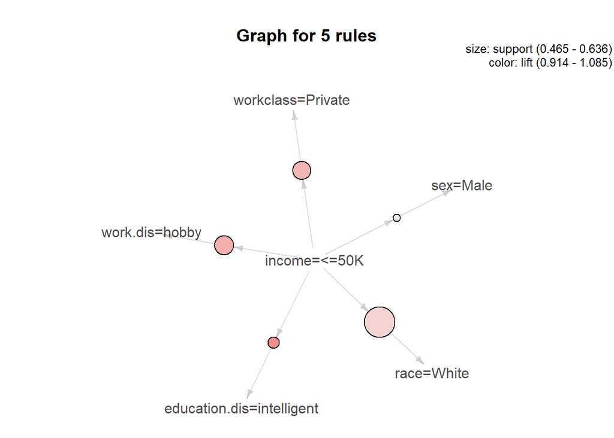

```r
plot(income_below,method="graph")
```

This perspective didn’t show much of a differentiation. That’s why income <=50K will be put on the right side.

```r
income_below_r = apriori(census_tran_rul,parameter=list(supp=.01,conf=.6,minlen=2),appearance = list(default="lhs",rhs="income=<=50K"))
```

```
## Apriori
##
## Parameter specification:
##  confidence minval smax arem  aval originalSupport maxtime support minlen
##         0.6    0.1    1 none FALSE            TRUE       5    0.01      2
##  maxlen target  ext
##      10  rules TRUE
##
## Algorithmic control:
##  filter tree heap memopt load sort verbose
##     0.1 TRUE TRUE  FALSE TRUE    2    TRUE
##
## Absolute minimum support count: 325
##
## set item appearances ...[1 item(s)] done [0.00s].
## set transactions ...[36 item(s), 32561 transaction(s)] done [0.02s].
## sorting and recoding items ... [34 item(s)] done [0.00s].
## creating transaction tree ... done [0.01s].
## checking subsets of size 1 2 3 4 5 6 7 8 9 done [0.02s].
## writing ... [3071 rule(s)] done [0.00s].
## creating S4 object  ... done [0.00s].
```

```r
summary(income_below_r)
```

```
## set of 3071 rules
##
## rule length distribution (lhs + rhs):sizes
##    2    3    4    5    6    7    8    9
##   27  230  710 1025  738  279   57    5
##
##    Min. 1st Qu.  Median    Mean 3rd Qu.    Max.
##   2.000   4.000   5.000   5.077   6.000   9.000
##
## summary of quality measures:
##     support          confidence        coverage            lift
##  Min.   :0.01001   Min.   :0.6002   Min.   :0.01004   Min.   :0.7905
##  1st Qu.:0.01357   1st Qu.:0.7894   1st Qu.:0.01585   1st Qu.:1.0398
##  Median :0.02055   Median :0.9119   Median :0.02365   Median :1.2011
##  Mean   :0.03675   Mean   :0.8733   Mean   :0.04354   Mean   :1.1503
##  3rd Qu.:0.03771   3rd Qu.:0.9705   3rd Qu.:0.04433   3rd Qu.:1.2783
##  Max.   :0.63570   Max.   :1.0000   Max.   :0.85427   Max.   :1.3172
##      count
##  Min.   :  326
##  1st Qu.:  442
##  Median :  669
##  Mean   : 1197
##  3rd Qu.: 1228
##  Max.   :20699
##
## mining info:
##             data ntransactions support confidence
##  census_tran_rul         32561    0.01        0.6
```

Significantly more rules were generated. 3071 is a high number. Rendundancy check will show how many of them aren’t needed.

```r
income_below_sorted = income_below_r[!is.redundant(income_below_r)]
summary(income_below_sorted)
```

```
## set of 520 rules
##
## rule length distribution (lhs + rhs):sizes
##   2   3   4   5   6   7   8
##  27  91 175 155  54  14   4
##
##    Min. 1st Qu.  Median    Mean 3rd Qu.    Max.
##   2.000   4.000   4.000   4.338   5.000   8.000
##
## summary of quality measures:
##     support          confidence        coverage            lift
##  Min.   :0.01004   Min.   :0.6319   Min.   :0.01010   Min.   :0.8324
##  1st Qu.:0.01529   1st Qu.:0.9471   1st Qu.:0.01551   1st Qu.:1.2475
##  Median :0.02346   Median :0.9766   Median :0.02397   Median :1.2864
##  Mean   :0.05049   Mean   :0.9585   Mean   :0.05559   Mean   :1.2625
##  3rd Qu.:0.04765   3rd Qu.:0.9901   3rd Qu.:0.04877   3rd Qu.:1.3041
##  Max.   :0.63570   Max.   :1.0000   Max.   :0.85427   Max.   :1.3172
##      count
##  Min.   :  327
##  1st Qu.:  498
##  Median :  764
##  Mean   : 1644
##  3rd Qu.: 1552
##  Max.   :20699
##
## mining info:
##             data ntransactions support confidence
##  census_tran_rul         32561    0.01        0.6
```

A lot of rules were dropped. 520 rules are now remaining. First 5 rules with the highest lift metric will be shown. Plot will describe how the associations were computed.

```r
inspect(head(sort(income_below_sorted, by ="lift"),5))
```

```
##     lhs                         rhs               support confidence   coverage     lift count
## [1] {marital.status=Single,
##      education.dis=educated,
##      work.dis=free}          => {income=<=50K} 0.01311385          1 0.01311385 1.317193   427
## [2] {age.dis=young,
##      education.dis=educated,
##      work.dis=free}          => {income=<=50K} 0.01323669          1 0.01323669 1.317193   431
## [3] {marital.status=Single,
##      sex=Female,
##      education.dis=educated} => {income=<=50K} 0.01412733          1 0.01412733 1.317193   460
## [4] {occupation=Sales,
##      age.dis=young,
##      work.dis=free}          => {income=<=50K} 0.01010411          1 0.01010411 1.317193   329
## [5] {marital.status=Single,
##      occupation=Other,
##      sex=Female,
##      age.dis=young}          => {income=<=50K} 0.01087190          1 0.01087190 1.317193   354
```

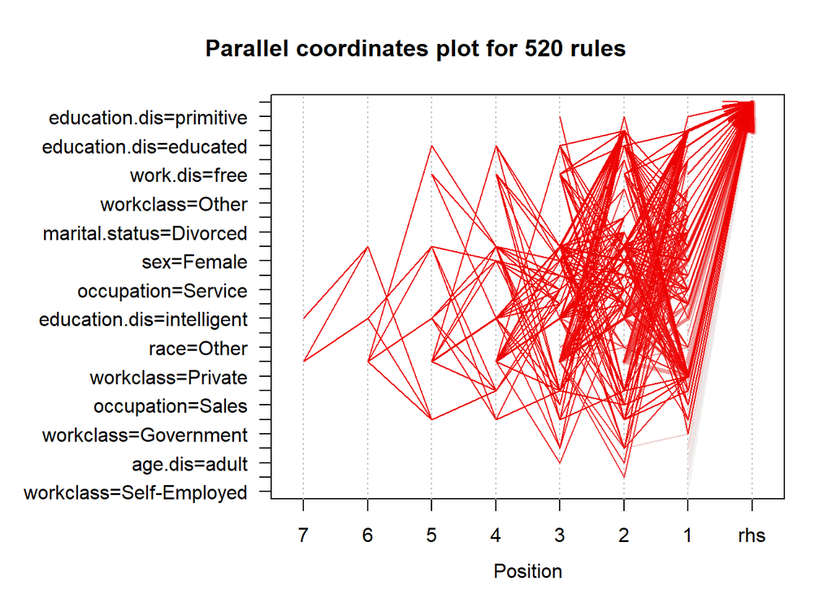

```r
plot(income_below_sorted,method="paracoord")
```

This paracoord shows that education, workclass and marital status are the most dependant on the income. The lower are their values, the higher is the probability of having <=50K *income*.

## **Final Rating**

### **80/20 % Performance**

```r
logi_1 = prediction(prob_1, census_test_1$income)
logi_1_f = performance(logi_1, measure = "tpr", x.measure = "fpr")
logi_1_d = data.frame(FP = logi_1_f@x.values[[1]], TP = logi_1_f@y.values[[1]])

cart_1 = prediction(tree_1.pred.prob[,2], census_test_1$income)
cart_1_f = performance(cart_1, measure = "tpr", x.measure = "fpr")
cart_1_d = data.frame(FP = cart_1_f@x.values[[1]], TP = cart_1_f@y.values[[1]])

randf_1 = prediction(rf_1.pred.prob[,2], census_test_1$income)
randf_1_f = performance(randf_1, measure = "tpr", x.measure = "fpr")
randf_1_d = data.frame(FP = randf_1_f@x.values[[1]], TP = randf_1_f@y.values[[1]])

nb_1 = as.numeric(NB_prediction_1)
naive_1 = prediction(nb_1, census_test_1$income)
naive_1_f = performance(naive_1, measure = "tpr", x.measure = "fpr")
naive_1_d = data.frame(FP = naive_1_f@x.values[[1]], TP = naive_1_f@y.values[[1]])

c_1 = as.numeric(census_pred_1_5)
clust_1 = prediction(c_1, census.testLabels_1)
clust_1_f = performance(clust_1, measure = "tpr", x.measure = "fpr")
clust_1_d = data.frame(FP = clust_1_f@x.values[[1]], TP = clust_1_f@y.values[[1]])

c_1_10 = as.numeric(census_pred_1_10)
clust_1_10 = prediction(c_1_10, census.testLabels_1)
clust_1_f_10 = performance(clust_1_10, measure = "tpr", x.measure = "fpr")
clust_1_d_10 = data.frame(FP = clust_1_f_10@x.values[[1]], TP = clust_1_f_10@y.values[[1]])

c_1_15 = as.numeric(census_pred_1_15)
clust_1_15 = prediction(c_1_15, census.testLabels_1)
clust_1_f_15 = performance(clust_1_15, measure = "tpr", x.measure = "fpr")
clust_1_d_15 = data.frame(FP = clust_1_f_15@x.values[[1]], TP = clust_1_f_15@y.values[[1]])

rule_1_this = as.numeric(predd_1)
rule_1 = prediction(rule_1_this, census_fact_1_ts$income)
rule_1_f = performance(rule_1, measure = "tpr", x.measure = "fpr")
rule_1_d = data.frame(FP = rule_1_f@x.values[[1]], TP = rule_1_f@y.values[[1]])
```

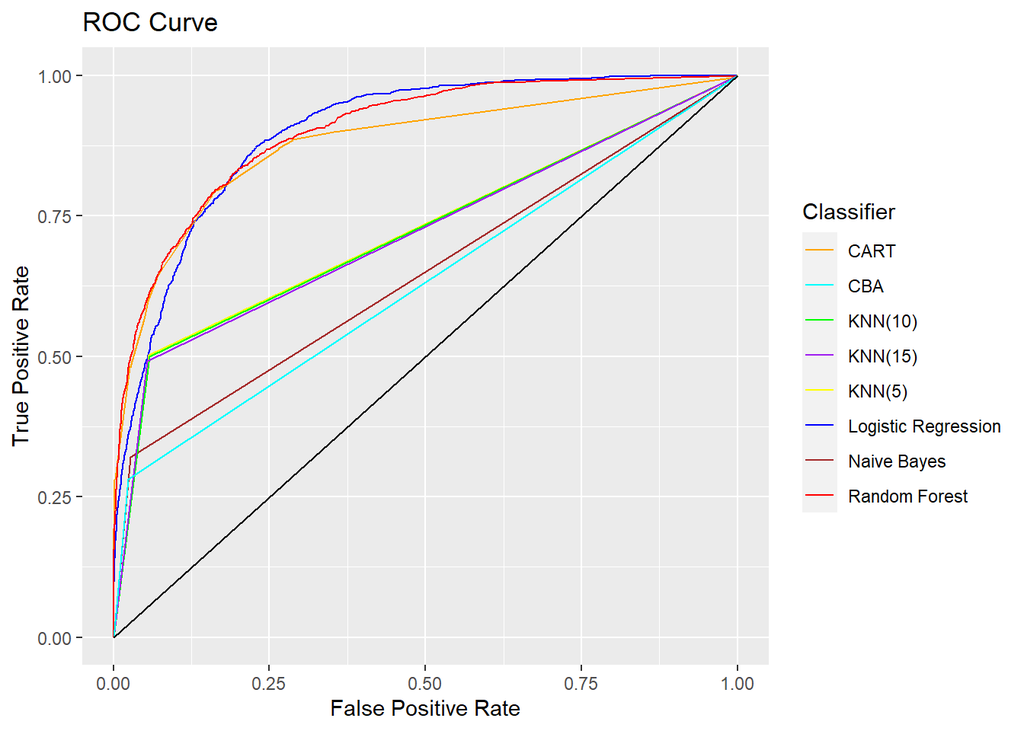

```r
g_1 = ggplot() +
  geom_line(data = logi_1_d, aes(x = FP, y = TP, color = 'Logistic Regression')) +
  geom_line(data = cart_1_d, aes(x = FP, y = TP, color = 'CART')) +
  geom_line(data = randf_1_d, aes(x = FP, y = TP, color = 'Random Forest')) +
  geom_line(data = naive_1_d, aes(x = FP, y = TP, color = 'Naive Bayes')) +
  geom_line(data = clust_1_d, aes(x = FP, y = TP, color = 'KNN(5)')) +
  geom_line(data = clust_1_d_10, aes(x = FP, y = TP, color = 'KNN(10)')) +
  geom_line(data = clust_1_d_15, aes(x = FP, y = TP, color = 'KNN(15)')) +
  geom_line(data = rule_1_d, aes(x = FP, y = TP, color = 'CBA')) +
  geom_segment(aes(x = 0, xend = 1, y = 0, yend = 1)) +
  ggtitle('ROC Curve') +
  labs(x = 'False Positive Rate', y = 'True Positive Rate')


g_1 +  scale_colour_manual(name = 'Classifier', values = c('Logistic Regression'='blue',
                                               'CART'='orange', 'Random Forest'='red',
                                               'Naive Bayes'='brown', 'KNN(5)'='yellow', 'KNN(10)'='green', 'KNN(15)'='purple', 'CBA'='cyan' ))
```

```r
auc_1 = rbind(performance(logi_1, measure = 'auc')@y.values[[1]],
             performance(cart_1, measure = 'auc')@y.values[[1]],
             performance(randf_1, measure = 'auc')@y.values[[1]],
             performance(naive_1, measure = 'auc')@y.values[[1]],
             performance(clust_1, measure = 'auc')@y.values[[1]],
             performance(clust_1_10, measure = 'auc')@y.values[[1]],
             performance(clust_1_15, measure = 'auc')@y.values[[1]],
             performance(rule_1, measure = 'auc')@y.values[[1]])

rownames(auc_1) = (c('Logistic Regression', 'CART', 'Random Forest',
                                    'Naive Bayes', 'KNN(5)', 'KNN(10)', 'KNN(15)', 'CBA'))
colnames(auc_1) = 'Area Under ROC Curve'

round(auc_1, 4)
```

```
##                     Area Under ROC Curve
## Logistic Regression               0.8977
## CART                              0.8772
## Random Forest                     0.9010
## Naive Bayes                       0.6465
## KNN(5)                            0.7226
## KNN(10)                           0.7204
## KNN(15)                           0.7189
## CBA                               0.6290
```

Logistic Regression, CART and Random Forest classifiers have the highest AUC values, while the other have lower results. Which is self explanatory due to their complexity and high prediction accuracy results, which were shown in the confusion matrix.

### **70/30 % Performance**

```r
logi_2 = prediction(prob_2, census_test_2$income)
logi_2_f = performance(logi_2, measure = "tpr", x.measure = "fpr")
logi_2_d = data.frame(FP = logi_2_f@x.values[[1]], TP = logi_2_f@y.values[[1]])

cart_2 = prediction(tree_2.pred.prob[,2], census_test_2$income)
cart_2_f = performance(cart_2, measure = "tpr", x.measure = "fpr")
cart_2_d = data.frame(FP = cart_2_f@x.values[[1]], TP = cart_2_f@y.values[[1]])

randf_2 = prediction(rf_2.pred.prob[,2], census_test_2$income)
randf_2_f = performance(randf_2, measure = "tpr", x.measure = "fpr")
randf_2_d = data.frame(FP = randf_2_f@x.values[[1]], TP = randf_2_f@y.values[[1]])

nb_2 = as.numeric(NB_prediction_2)
naive_2 = prediction(nb_2, census_test_2$income)
naive_2_f = performance(naive_2, measure = "tpr", x.measure = "fpr")
naive_2_d = data.frame(FP = naive_2_f@x.values[[1]], TP = naive_2_f@y.values[[1]])

c_2 = as.numeric(census_pred_2_5)
clust_2 = prediction(c_2, census.testLabels_2)
clust_2_f = performance(clust_2, measure = "tpr", x.measure = "fpr")
clust_2_d = data.frame(FP = clust_2_f@x.values[[1]], TP = clust_2_f@y.values[[1]])

c_2_10 = as.numeric(census_pred_2_10)
clust_2_10 = prediction(c_2_10, census.testLabels_2)
clust_2_f_10 = performance(clust_2_10, measure = "tpr", x.measure = "fpr")
clust_2_d_10 = data.frame(FP = clust_2_f_10@x.values[[1]], TP = clust_2_f_10@y.values[[1]])

c_2_15 = as.numeric(census_pred_2_15)
clust_2_15 = prediction(c_2_15, census.testLabels_2)
clust_2_f_15 = performance(clust_2_15, measure = "tpr", x.measure = "fpr")
clust_2_d_15 = data.frame(FP = clust_2_f_15@x.values[[1]], TP = clust_2_f_15@y.values[[1]])

rule_2_this = as.numeric(predd_2)
rule_2 = prediction(rule_2_this, census_fact_2_ts$income)
rule_2_f = performance(rule_2, measure = "tpr", x.measure = "fpr")
rule_2_d = data.frame(FP = rule_2_f@x.values[[1]], TP = rule_2_f@y.values[[1]])
```

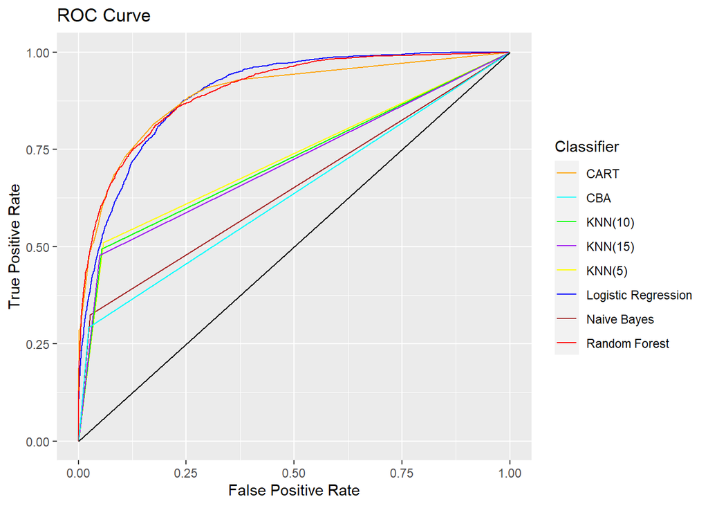

```r
g_2 = ggplot() +
  geom_line(data = logi_2_d, aes(x = FP, y = TP, color = 'Logistic Regression')) +
  geom_line(data = cart_2_d, aes(x = FP, y = TP, color = 'CART')) +
  geom_line(data = randf_2_d, aes(x = FP, y = TP, color = 'Random Forest')) +
  geom_line(data = naive_2_d, aes(x = FP, y = TP, color = 'Naive Bayes')) +
  geom_line(data = clust_2_d, aes(x = FP, y = TP, color = 'KNN(5)')) +
  geom_line(data = clust_2_d_10, aes(x = FP, y = TP, color = 'KNN(10)')) +
  geom_line(data = clust_2_d_15, aes(x = FP, y = TP, color = 'KNN(15)')) +
  geom_line(data = rule_2_d, aes(x = FP, y = TP, color = 'CBA')) +
  geom_segment(aes(x = 0, xend = 1, y = 0, yend = 1)) +
  ggtitle('ROC Curve') +
  labs(x = 'False Positive Rate', y = 'True Positive Rate')


g_2 +  scale_colour_manual(name = 'Classifier', values = c('Logistic Regression'='blue',
                                               'CART'='orange', 'Random Forest'='red',
                                               'Naive Bayes'='brown', 'KNN(5)'='yellow', 'KNN(10)'='green', 'KNN(15)'='purple', 'CBA' = 'cyan'))
```

```r
auc_2 = rbind(performance(logi_2, measure = 'auc')@y.values[[1]],
             performance(cart_2, measure = 'auc')@y.values[[1]],
             performance(randf_2, measure = 'auc')@y.values[[1]],
             performance(naive_2, measure = 'auc')@y.values[[1]],
             performance(clust_2, measure = 'auc')@y.values[[1]],
             performance(clust_2_10, measure = 'auc')@y.values[[1]],
             performance(clust_2_15, measure = 'auc')@y.values[[1]],
             performance(rule_2, measure = 'auc')@y.values[[1]])

rownames(auc_2) = (c('Logistic Regression', 'CART', 'Random Forest',
                                    'Naive Bayes', 'KNN(5)', 'KNN(10)', 'KNN(15)', 'CBA'))
colnames(auc_2) = 'Area Under ROC Curve'

round(auc_2, 4)
```

```
##                     Area Under ROC Curve
## Logistic Regression               0.8966
## CART                              0.8933
## Random Forest                     0.9013
## Naive Bayes                       0.6485
## KNN(5)                            0.7259
## KNN(10)                           0.7202
## KNN(15)                           0.7145
## CBA                               0.6342
```

Logistic regression, CART and Random Forest classifiers are still on the winning positions. However, the Logistic Regression has decreased, CART shows significantly better performance.

### **60/40 % Performance**

```r
logi_3 = prediction(prob_3, census_test_3$income)
logi_3_f = performance(logi_3, measure = "tpr", x.measure = "fpr")
logi_3_d = data.frame(FP = logi_3_f@x.values[[1]], TP = logi_3_f@y.values[[1]])

cart_3 = prediction(tree_3.pred.prob[,2], census_test_3$income)
cart_3_f = performance(cart_3, measure = "tpr", x.measure = "fpr")
cart_3_d = data.frame(FP = cart_3_f@x.values[[1]], TP = cart_3_f@y.values[[1]])

randf_3 = prediction(rf_3.pred.prob[,2], census_test_3$income)
randf_3_f = performance(randf_3, measure = "tpr", x.measure = "fpr")
randf_3_d = data.frame(FP = randf_3_f@x.values[[1]], TP = randf_3_f@y.values[[1]])

nb_3 = as.numeric(NB_prediction_3)
naive_3 = prediction(nb_3, census_test_3$income)
naive_3_f = performance(naive_3, measure = "tpr", x.measure = "fpr")
naive_3_d = data.frame(FP = naive_3_f@x.values[[1]], TP = naive_3_f@y.values[[1]])

c_3 = as.numeric(census_pred_3_5)
clust_3 = prediction(c_3, census.testLabels_3)
clust_3_f = performance(clust_3, measure = "tpr", x.measure = "fpr")
clust_3_d = data.frame(FP = clust_3_f@x.values[[1]], TP = clust_3_f@y.values[[1]])

c_3_10 = as.numeric(census_pred_3_10)
clust_3_10 = prediction(c_3_10, census.testLabels_3)
clust_3_f_10 = performance(clust_3_10, measure = "tpr", x.measure = "fpr")
clust_3_d_10 = data.frame(FP = clust_3_f_10@x.values[[1]], TP = clust_3_f_10@y.values[[1]])

c_3_15 = as.numeric(census_pred_3_15)
clust_3_15 = prediction(c_3_15, census.testLabels_3)
clust_3_f_15 = performance(clust_3_15, measure = "tpr", x.measure = "fpr")
clust_3_d_15 = data.frame(FP = clust_3_f_15@x.values[[1]], TP = clust_3_f_15@y.values[[1]])

rule_3_this = as.numeric(predd_3)
rule_3 = prediction(rule_3_this, census_fact_3_ts$income)
rule_3_f = performance(rule_3, measure = "tpr", x.measure = "fpr")
rule_3_d = data.frame(FP = rule_3_f@x.values[[1]], TP = rule_3_f@y.values[[1]])
```

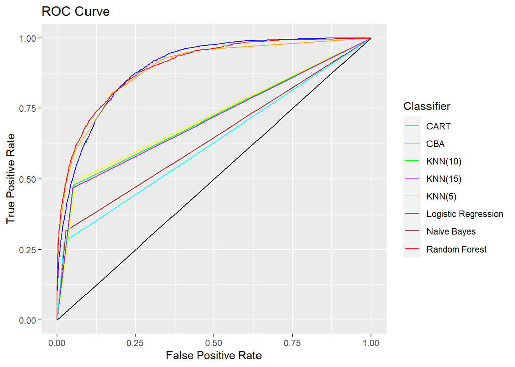

```r
g_3 = ggplot() +
  geom_line(data = logi_3_d, aes(x = FP, y = TP, color = 'Logistic Regression')) +
  geom_line(data = cart_3_d, aes(x = FP, y = TP, color = 'CART')) +
  geom_line(data = randf_3_d, aes(x = FP, y = TP, color = 'Random Forest')) +
  geom_line(data = naive_3_d, aes(x = FP, y = TP, color = 'Naive Bayes')) +
  geom_line(data = clust_3_d, aes(x = FP, y = TP, color = 'KNN(5)')) +
  geom_line(data = clust_3_d_10, aes(x = FP, y = TP, color = 'KNN(10)')) +
  geom_line(data = clust_3_d_15, aes(x = FP, y = TP, color = 'KNN(15)')) +
  geom_line(data = rule_3_d, aes(x = FP, y = TP, color = 'CBA')) +
  geom_segment(aes(x = 0, xend = 1, y = 0, yend = 1)) +
  ggtitle('ROC Curve') +
  labs(x = 'False Positive Rate', y = 'True Positive Rate')


g_3 +  scale_colour_manual(name = 'Classifier', values = c('Logistic Regression'='blue',
                                               'CART'='orange', 'Random Forest'='red',
                                               'Naive Bayes'='brown', 'KNN(5)'='yellow', 'KNN(10)'='green', 'KNN(15)'='purple', 'CBA'='cyan'))
```

```r
auc_3 = rbind(performance(logi_3, measure = 'auc')@y.values[[1]],
             performance(cart_3, measure = 'auc')@y.values[[1]],
             performance(randf_3, measure = 'auc')@y.values[[1]],
             performance(naive_3, measure = 'auc')@y.values[[1]],
             performance(clust_3, measure = 'auc')@y.values[[1]],
             performance(clust_3_10, measure = 'auc')@y.values[[1]],
             performance(clust_3_15, measure = 'auc')@y.values[[1]],
             performance(rule_3, measure = 'auc')@y.values[[1]])

rownames(auc_3) = (c('Logistic Regression', 'CART', 'Random Forest',
                                    'Naive Bayes', 'KNN(5)', 'KNN(10)', 'KNN(15)', 'CBA'))
colnames(auc_3) = 'Area Under ROC Curve'

round(auc_3, 4)
```

```
##                     Area Under ROC Curve
## Logistic Regression               0.8960
## CART                              0.8930
## Random Forest                     0.8995
## Naive Bayes                       0.6432
## KNN(5)                            0.7166
## KNN(10)                           0.7128
## KNN(15)                           0.7091
## CBA                               0.6268
```

Needless to say, the 60/40 % split shows the worst performance by “harming” the accuracy of the first 3 classifiers.

## **Table of the Final Performance**

Here will be shown all Area Under ROC performance metrics to compare how well did the models classify *income*.

[output not shown]

# **Conclusion**

To sum up, Census Income data set analysis has shown incredible results in the *income* category classification, despite the class imbalance. Different train/test splits were used, while the 70/30 % had performed the best. Out of all chosen classification models three of them achieved above 89% prediction accuracy. Data Preprocessing phase did a great job in improving the modeling phase. Descriptive analytic has shown how dependant *income* is . That’s why Logistic Regression, CART and Random Forest classifiers performed so well.

[figure not shown]

Thanks